# Midterm_spring2025_online

```python
#Run the following code to print multiple outputs from a cell
get_ipython().ast_node_interactivity = 'all'
```

## Midterm Exam - Part 2 Questions

For the following questions, use the data file: dataTickets1.csv (already uploaded to Jupyter Hub).

The data set contains information about drivers who were stopped for speeding in Massachusetts for 2 months in 2002. The file has the following information (columns):

- Gender - the driver's gender (male or female)
- Amount - amount of the speeding ticket (in US$)
- MPHover - # of miles per hour over the speed limit
- Age - the driver's age in years
- OutTown - 1=driver is from out of town, 0=driver is from in town
- OutState - 1=driver is from out of state, 0=driver is from in state
- Police - whether the officer was from the state or local police

### Question 1. (6 points)

Read in the data file (dataTickets1.csv), display the data types, and how many missing values there are.

**No explanation needed for this question**

```python
# Your code goes here:
import pandas as pd
df = pd.read_csv("dataTickets1.csv")
```

```python
df
```

|  | Gender | Amount | MPHover | Age | OutTown | OutState | Police |
| --- | --- | --- | --- | --- | --- | --- | --- |
| 0 | female | 75.0 | 18 | 26 | 1 | 0 | local police |
| 1 | female | NaN | 18 | 55 | 0 | 0 | local police |
| 2 | female | NaN | 14 | 44 | 1 | 0 | local police |
| 3 | male | 50.0 | 10 | 25 | 1 | 0 | state police |
| 4 | male | NaN | 12 | 23 | 1 | 1 | local police |
| ... | ... | ... | ... | ... | ... | ... | ... |
| 9995 | male | NaN | 14 | 39 | 0 | 0 | local police |
| 9996 | male | NaN | 5 | 19 | 1 | 1 | state police |
| 9997 | male | NaN | 17 | 21 | 0 | 0 | local police |
| 9998 | female | NaN | 10 | 19 | 1 | 0 | local police |
| 9999 | female | 75.0 | 19 | 59 | 0 | 0 | local police |

10000 rows × 7 columns

### Question 2. (8 points)

Profile the `MPHover` variable. In your profile, calculate summary statistics and draw an appropriate graph showing the variable's distribution. In the space below, write several sentences describing the variable's shape and providing a measure of center and measure of spread. Also comment on any anomalies with this variable.

**Double-click to type your answer here**

```
count    10000.000000
mean        15.194900
std          5.132285
min          1.000000
25%         11.000000
50%         15.000000
75%         18.000000
max         55.000000
Name: MPHover, dtype: float64
```

```
np.int64(0)
```

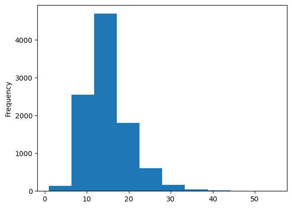

```python
# Your code goes here:
df["MPHover"].describe()
df["MPHover"].plot.hist()
df["MPHover"].isna().sum()
# rf: MPHover is mph over the limit, as one might expect this sharply jumps
# to 10 mph and around 18mph, and then steadily drops off from there

# no nulls, a max of 55 might be incorrectly reported as the actual speed
# unless someone was doing 75 in a 20, yikes!
```

### Question 3. (6 points)

Profile the `OutTown` variable. Get the **count** of out-of-town versus in-town drivers and draw an appropriate graph to display the **proportion** of each. In the space below, write 1-2 sentences describing the distribution of out-of-town vs. in-town drivers in this data set.

*Note: 1=driver is from out of town, 0=driver is from in town*

**Double-click to type your answer here**

```
<bound method NDFrame.describe of 0       1
1       0
2       1
3       1
4       1
       ..
9995    0
9996    1
9997    0
9998    1
9999    0
Name: OutTown, Length: 10000, dtype: int64>
```

```
OutTown
1    7769
0    2231
Name: count, dtype: int64
```

```
OutTown
1    0.7769
0    0.2231
Name: proportion, dtype: float64
```

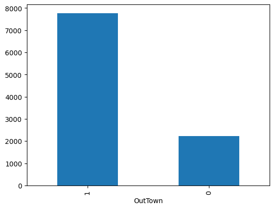

```python
# Your code goes here:
df["OutTown"].describe
df["OutTown"].value_counts()

# more out of towners than not

df["OutTown"].value_counts().plot.bar()

df["OutTown"].value_counts(normalize=True)
```

### Question 4. (3 points)

Create a contingency table showing the proportions of `Gender` (in the rows) vs. `Police` (in the columns). Your proportions should be calculated out of the total counts for each gender (in the rows). From your table, does it appear that there's a relationship between the 2 variables? (E.g., does it appear that female drivers are stopped more or less often by local police than males?)

**Double-click to type your answer here**

```python
# Your code goes here:
pd.crosstab(df["Gender"], df["Police"], margins=True, normalize="all")
# male drivers are stopped more frequently by both state and local police
```

| Police Gender | local police | state police | All |
| --- | --- | --- | --- |
| female | 0.3056 | 0.0883 | 0.3939 |
| male | 0.4289 | 0.1772 | 0.6061 |
| All | 0.7345 | 0.2655 | 1.0000 |

### Question 5. (3 points)

How many drivers had an mph that was over the speed limit by 25 mph or more? (You must use the `.loc` command to answer this question.)

**Double-click to type your answer here**

```python
# Your code goes here:
df["MPHover"].loc[df["MPHover"] >= 25].count()

# 556 wow!
```

```
np.int64(556)
```

### Question 6. (6 points)

Filter the data set to show the ticket amount, mph over, and gender for drivers who are male and were driving less than 20 mph over the speed limit. Show **only** the `Amount`, `MPHover`, and `Gender` columns and order it low to high based on `Amount`. (You must use the `.loc` command to answer this question.)

**No explanation needed for this question**

```python
# Your code goes here:
df.loc[(df["Gender"] == "male") & (df["MPHover"] < 20), ["Amount", "MPHover", "Gender"]]
```

|  | Amount | MPHover | Gender |
| --- | --- | --- | --- |
| 3 | 50.0 | 10 | male |
| 4 | NaN | 12 | male |
| 5 | NaN | 10 | male |
| 6 | 105.0 | 13 | male |
| 7 | NaN | 15 | male |
| ... | ... | ... | ... |
| 9993 | NaN | 12 | male |
| 9994 | NaN | 18 | male |
| 9995 | NaN | 14 | male |
| 9996 | NaN | 5 | male |
| 9997 | NaN | 17 | male |

4859 rows × 3 columns

### Question 7. (3 points)

You're curious if gender has an effect on the amount of someone's speeding ticket. Draw an appropriate graph to show if the `Amount` differs based on `Gender`.

**No explanation needed for this question**

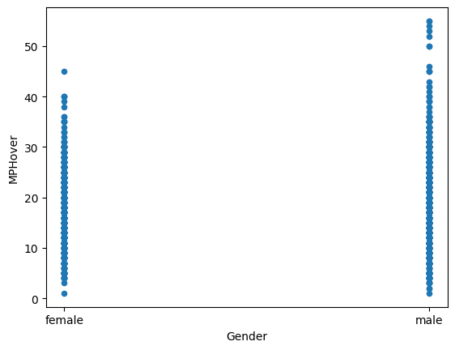

```python
# Your code goes here:
df.plot.scatter(x = "Gender", y = "MPHover")
```

### Question 8. (3 points)

You're curious about the relationship between how fast someone was going (`MPHover`) and the amount of their speeding ticket (`Amount`). Draw an appropriate graph to show the relationship between these 2 variables.

**No explanation needed for this question**

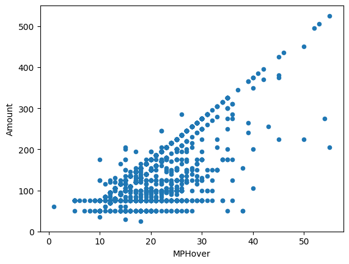

```python
# Your code goes here:
df.plot.scatter(x = "MPHover", y = "Amount")
```

### Question 9. (5 points)

What day of the week was it on August 10, 1993? Figure this out using python (and not a calendar).

**Double-click to type your answer here**

```python
# Your code goes here:
import datetime
x = datetime.date(1993, 8, 10)
x.weekday() # Monday is 0 so 1 = Tuesday
```

```
1
```

### Question 10 (2 points)

There is a function called `exp()` in the `math` package that will raise the constant `e` to the power of whatever number you provide. If you run the code in the following code cell, you'll get an error message. Fix the code to raise `e` to the power of 4.

**No explanation needed for this question**

```python
# Your code goes here:
import math
math.exp(4)
```

```
54.598150033144236
```

### Once you've finished, save and export your notebook as an HTML file and upload it to question 5 in Canvas.

From the File menu, click "Save and Export Notebook As" and then select HTML.

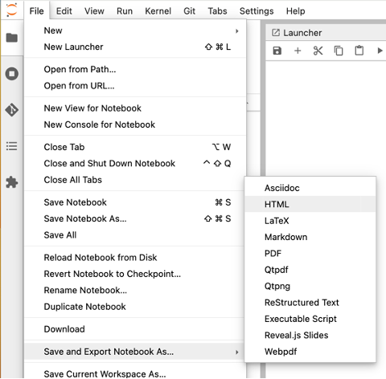